# wrangle_act

## Gather 收集数据

```python
import pandas as pd
import numpy as np
import requests
import json
import matplotlib.pyplot as plt
import seaborn as sns
sns.set_style('darkgrid')
```

```python
#gather data by loading csv file

dogs_rate = pd.read_csv('twitter-archive-enhanced.csv')
```

```python
dogs_rate.head()
```

|  | Unnamed: 0 | tweet_id | in_reply_to_status_id | in_reply_to_user_id | timestamp | source | text | retweeted_status_id | retweeted_status_user_id | retweeted_status_timestamp | expanded_urls | rating_numerator | rating_denominator | name | doggo | floofer | pupper | puppo |
| --- | --- | --- | --- | --- | --- | --- | --- | --- | --- | --- | --- | --- | --- | --- | --- | --- | --- | --- |
| 0 | 0 | 892420643555336193 | NaN | NaN | 2017-08-01 16:23:56 +0000 | <a href="http://twitter.com/download/iphone" r... | This is Phineas. He's a mystical boy. Only eve... | NaN | NaN | NaN | https://twitter.com/dog_rates/status/892420643... | 13 | 10 | Phineas | None | None | None | None |
| 1 | 1 | 892177421306343426 | NaN | NaN | 2017-08-01 00:17:27 +0000 | <a href="http://twitter.com/download/iphone" r... | This is Tilly. She's just checking pup on you.... | NaN | NaN | NaN | https://twitter.com/dog_rates/status/892177421... | 13 | 10 | Tilly | None | None | None | None |
| 2 | 2 | 891815181378084864 | NaN | NaN | 2017-07-31 00:18:03 +0000 | <a href="http://twitter.com/download/iphone" r... | This is Archie. He is a rare Norwegian Pouncin... | NaN | NaN | NaN | https://twitter.com/dog_rates/status/891815181... | 12 | 10 | Archie | None | None | None | None |
| 3 | 3 | 891689557279858688 | NaN | NaN | 2017-07-30 15:58:51 +0000 | <a href="http://twitter.com/download/iphone" r... | This is Darla. She commenced a snooze mid meal... | NaN | NaN | NaN | https://twitter.com/dog_rates/status/891689557... | 13 | 10 | Darla | None | None | None | None |
| 4 | 4 | 891327558926688256 | NaN | NaN | 2017-07-29 16:00:24 +0000 | <a href="http://twitter.com/download/iphone" r... | This is Franklin. He would like you to stop ca... | NaN | NaN | NaN | https://twitter.com/dog_rates/status/891327558... | 12 | 10 | Franklin | None | None | None | None |

```python
#gather data from internet

# Use requests library to download tsv file from a website
url="https://raw.githubusercontent.com/udacity/new-dand-advanced-china/master/%E6%95%B0%E6%8D%AE%E6%B8%85%E6%B4%97/WeRateDogs%E9%A1%B9%E7%9B%AE/image-predictions.tsv"
response = requests.get(url)

with open('image_predictions.tsv', 'wb') as file:
    file.write(response.content)

# Read in tsv file as a Pandas DataFrame
image = pd.read_csv('image_predictions.tsv', sep='\t')
```

```python
# List of dictionaries to build file by file and later convert to a DataFrame
tweet_list = []

with open ('tweet_json.txt','r')as f:
    for line in f :
        json_line= json.loads(line)

        tweet_list.append({'tweet_id':json_line['id'],
                           'retweet_count':json_line['retweet_count'],
                           'favorite_count':json_line['favorite_count']})
tweet_df = pd.DataFrame(tweet_list, columns=['tweet_id','retweet_count','favorite_count'])
```

## Access 评估数据

```python
#access dogs_rate table
dogs_rate.head()
```

|  | Unnamed: 0 | tweet_id | in_reply_to_status_id | in_reply_to_user_id | timestamp | source | text | retweeted_status_id | retweeted_status_user_id | retweeted_status_timestamp | expanded_urls | rating_numerator | rating_denominator | name | doggo | floofer | pupper | puppo |
| --- | --- | --- | --- | --- | --- | --- | --- | --- | --- | --- | --- | --- | --- | --- | --- | --- | --- | --- |
| 0 | 0 | 892420643555336193 | NaN | NaN | 2017-08-01 16:23:56 +0000 | <a href="http://twitter.com/download/iphone" r... | This is Phineas. He's a mystical boy. Only eve... | NaN | NaN | NaN | https://twitter.com/dog_rates/status/892420643... | 13 | 10 | Phineas | None | None | None | None |
| 1 | 1 | 892177421306343426 | NaN | NaN | 2017-08-01 00:17:27 +0000 | <a href="http://twitter.com/download/iphone" r... | This is Tilly. She's just checking pup on you.... | NaN | NaN | NaN | https://twitter.com/dog_rates/status/892177421... | 13 | 10 | Tilly | None | None | None | None |
| 2 | 2 | 891815181378084864 | NaN | NaN | 2017-07-31 00:18:03 +0000 | <a href="http://twitter.com/download/iphone" r... | This is Archie. He is a rare Norwegian Pouncin... | NaN | NaN | NaN | https://twitter.com/dog_rates/status/891815181... | 12 | 10 | Archie | None | None | None | None |
| 3 | 3 | 891689557279858688 | NaN | NaN | 2017-07-30 15:58:51 +0000 | <a href="http://twitter.com/download/iphone" r... | This is Darla. She commenced a snooze mid meal... | NaN | NaN | NaN | https://twitter.com/dog_rates/status/891689557... | 13 | 10 | Darla | None | None | None | None |
| 4 | 4 | 891327558926688256 | NaN | NaN | 2017-07-29 16:00:24 +0000 | <a href="http://twitter.com/download/iphone" r... | This is Franklin. He would like you to stop ca... | NaN | NaN | NaN | https://twitter.com/dog_rates/status/891327558... | 12 | 10 | Franklin | None | None | None | None |

```python
dogs_rate.tail()
```

|  | Unnamed: 0 | tweet_id | in_reply_to_status_id | in_reply_to_user_id | timestamp | source | text | retweeted_status_id | retweeted_status_user_id | retweeted_status_timestamp | expanded_urls | rating_numerator | rating_denominator | name | doggo | floofer | pupper | puppo |
| --- | --- | --- | --- | --- | --- | --- | --- | --- | --- | --- | --- | --- | --- | --- | --- | --- | --- | --- |
| 2351 | 2351 | 666049248165822465 | NaN | NaN | 2015-11-16 00:24:50 +0000 | <a href="http://twitter.com/download/iphone" r... | Here we have a 1949 1st generation vulpix. Enj... | NaN | NaN | NaN | https://twitter.com/dog_rates/status/666049248... | 5 | 10 | None | None | None | None | None |
| 2352 | 2352 | 666044226329800704 | NaN | NaN | 2015-11-16 00:04:52 +0000 | <a href="http://twitter.com/download/iphone" r... | This is a purebred Piers Morgan. Loves to Netf... | NaN | NaN | NaN | https://twitter.com/dog_rates/status/666044226... | 6 | 10 | a | None | None | None | None |
| 2353 | 2353 | 666033412701032449 | NaN | NaN | 2015-11-15 23:21:54 +0000 | <a href="http://twitter.com/download/iphone" r... | Here is a very happy pup. Big fan of well-main... | NaN | NaN | NaN | https://twitter.com/dog_rates/status/666033412... | 9 | 10 | a | None | None | None | None |
| 2354 | 2354 | 666029285002620928 | NaN | NaN | 2015-11-15 23:05:30 +0000 | <a href="http://twitter.com/download/iphone" r... | This is a western brown Mitsubishi terrier. Up... | NaN | NaN | NaN | https://twitter.com/dog_rates/status/666029285... | 7 | 10 | a | None | None | None | None |
| 2355 | 2355 | 666020888022790149 | NaN | NaN | 2015-11-15 22:32:08 +0000 | <a href="http://twitter.com/download/iphone" r... | Here we have a Japanese Irish Setter. Lost eye... | NaN | NaN | NaN | https://twitter.com/dog_rates/status/666020888... | 8 | 10 | None | None | None | None | None |

```python
dogs_rate.sample(5)
```

|  | Unnamed: 0 | tweet_id | in_reply_to_status_id | in_reply_to_user_id | timestamp | source | text | retweeted_status_id | retweeted_status_user_id | retweeted_status_timestamp | expanded_urls | rating_numerator | rating_denominator | name | doggo | floofer | pupper | puppo |
| --- | --- | --- | --- | --- | --- | --- | --- | --- | --- | --- | --- | --- | --- | --- | --- | --- | --- | --- |
| 847 | 847 | 766078092750233600 | NaN | NaN | 2016-08-18 01:03:45 +0000 | <a href="http://twitter.com/download/iphone" r... | RT @dog_rates: This is Colby. He's currently r... | 7.258423e+17 | 4.196984e+09 | 2016-04-29 00:21:01 +0000 | https://twitter.com/dog_rates/status/725842289... | 12 | 10 | Colby | None | None | None | None |
| 730 | 730 | 781661882474196992 | NaN | NaN | 2016-09-30 01:08:10 +0000 | <a href="http://twitter.com/download/iphone" r... | Who keeps sending in pictures without dogs in ... | NaN | NaN | NaN | https://twitter.com/dog_rates/status/781661882... | 5 | 10 | None | None | None | None | None |
| 252 | 252 | 844973813909606400 | NaN | NaN | 2017-03-23 18:07:10 +0000 | <a href="http://twitter.com/download/iphone" r... | This is Brady. He's a recovering alcoholic. De... | NaN | NaN | NaN | https://twitter.com/dog_rates/status/844973813... | 12 | 10 | Brady | None | None | None | None |
| 1236 | 1236 | 712438159032893441 | NaN | NaN | 2016-03-23 00:37:48 +0000 | <a href="http://twitter.com/download/iphone" r... | This is Kane. He's a semi-submerged Haitian Hu... | NaN | NaN | NaN | https://twitter.com/dog_rates/status/712438159... | 11 | 10 | Kane | None | None | None | None |
| 1972 | 1972 | 673240798075449344 | NaN | NaN | 2015-12-05 20:41:29 +0000 | <a href="http://twitter.com/download/iphone" r... | Magical floating dog here. Very calm. Always h... | NaN | NaN | NaN | https://twitter.com/dog_rates/status/673240798... | 6 | 10 | None | None | None | None | None |

```python
dogs_rate.source.value_counts()
```

```
<a href="http://twitter.com/download/iphone" rel="nofollow">Twitter for iPhone</a>     2221
<a href="http://vine.co" rel="nofollow">Vine - Make a Scene</a>                          91
<a href="http://twitter.com" rel="nofollow">Twitter Web Client</a>                       33
<a href="https://about.twitter.com/products/tweetdeck" rel="nofollow">TweetDeck</a>      11
Name: source, dtype: int64
```

```python
dogs_rate.name.value_counts()
```

```
None          745
a              55
Charlie        12
Cooper         11
Oliver         11
Lucy           11
Lola           10
Tucker         10
Penny          10
Bo              9
Winston         9
the             8
Sadie           8
Bailey          7
Daisy           7
an              7
Toby            7
Buddy           7
Dave            6
Koda            6
Rusty           6
Stanley         6
Jax             6
Leo             6
Scout           6
Oscar           6
Jack            6
Milo            6
Bella           6
Bentley         5
             ...
Flash           1
Butters         1
Blanket         1
Covach          1
Bronte          1
life            1
Karl            1
Danny           1
Ronnie          1
Major           1
Trevith         1
Ralphus         1
Sky             1
Superpup        1
Kanu            1
DayZ            1
Mookie          1
Cannon          1
Cilantro        1
Pavlov          1
Stewie          1
Kane            1
Karma           1
Horace          1
Benny           1
Banditt         1
Claude          1
officially      1
Mo              1
Edd             1
Name: name, Length: 957, dtype: int64
```

```python
dogs_rate.info()
```

```
<class 'pandas.core.frame.DataFrame'>
RangeIndex: 2356 entries, 0 to 2355
Data columns (total 18 columns):
Unnamed: 0                    2356 non-null int64
tweet_id                      2356 non-null int64
in_reply_to_status_id         78 non-null float64
in_reply_to_user_id           78 non-null float64
timestamp                     2356 non-null object
source                        2356 non-null object
text                          2356 non-null object
retweeted_status_id           181 non-null float64
retweeted_status_user_id      181 non-null float64
retweeted_status_timestamp    181 non-null object
expanded_urls                 2297 non-null object
rating_numerator              2356 non-null int64
rating_denominator            2356 non-null int64
name                          2356 non-null object
doggo                         2356 non-null object
floofer                       2356 non-null object
pupper                        2356 non-null object
puppo                         2356 non-null object
dtypes: float64(4), int64(4), object(10)
memory usage: 331.4+ KB
```

```python
dogs_rate.expanded_urls.isnull().sum()
```

```
59
```

```python
dogs_rate.rating_numerator.value_counts()
```

```
12      558
11      464
10      461
13      351
9       158
8       102
7        55
14       54
5        37
6        32
3        19
4        17
1         9
2         9
420       2
```

[output cut: 26 more lines]

```python
dogs_rate.rating_denominator.value_counts()
```

```
10     2333
11        3
50        3
80        2
20        2
2         1
16        1
40        1
70        1
15        1
90        1
110       1
120       1
130       1
150       1
170       1
7         1
0         1
Name: rating_denominator, dtype: int64
```

```python
dogs_rate.query("rating_denominator == 0")
```

|  | Unnamed: 0 | tweet_id | in_reply_to_status_id | in_reply_to_user_id | timestamp | source | text | retweeted_status_id | retweeted_status_user_id | retweeted_status_timestamp | expanded_urls | rating_numerator | rating_denominator | name | doggo | floofer | pupper | puppo |
| --- | --- | --- | --- | --- | --- | --- | --- | --- | --- | --- | --- | --- | --- | --- | --- | --- | --- | --- |
| 313 | 313 | 835246439529840640 | 8.352460e+17 | 26259576.0 | 2017-02-24 21:54:03 +0000 | <a href="http://twitter.com/download/iphone" r... | @jonnysun @Lin_Manuel ok jomny I know you're e... | NaN | NaN | NaN | NaN | 960 | 0 | None | None | None | None | None |

```python
dogs_rate.query("rating_denominator == 2")
```

|  | Unnamed: 0 | tweet_id | in_reply_to_status_id | in_reply_to_user_id | timestamp | source | text | retweeted_status_id | retweeted_status_user_id | retweeted_status_timestamp | expanded_urls | rating_numerator | rating_denominator | name | doggo | floofer | pupper | puppo |
| --- | --- | --- | --- | --- | --- | --- | --- | --- | --- | --- | --- | --- | --- | --- | --- | --- | --- | --- |
| 2335 | 2335 | 666287406224695296 | NaN | NaN | 2015-11-16 16:11:11 +0000 | <a href="http://twitter.com/download/iphone" r... | This is an Albanian 3 1/2 legged Episcopalian... | NaN | NaN | NaN | https://twitter.com/dog_rates/status/666287406... | 1 | 2 | an | None | None | None | None |

```python
dogs_rate.query("rating_denominator == 7")
```

|  | Unnamed: 0 | tweet_id | in_reply_to_status_id | in_reply_to_user_id | timestamp | source | text | retweeted_status_id | retweeted_status_user_id | retweeted_status_timestamp | expanded_urls | rating_numerator | rating_denominator | name | doggo | floofer | pupper | puppo |
| --- | --- | --- | --- | --- | --- | --- | --- | --- | --- | --- | --- | --- | --- | --- | --- | --- | --- | --- |
| 516 | 516 | 810984652412424192 | NaN | NaN | 2016-12-19 23:06:23 +0000 | <a href="http://twitter.com/download/iphone" r... | Meet Sam. She smiles 24/7 &amp; secretly aspir... | NaN | NaN | NaN | https://www.gofundme.com/sams-smile,https://tw... | 24 | 7 | Sam | None | None | None | None |

```python
dogs_rate.rating_numerator.describe()
```

```
count    2356.000000
mean       13.126486
std        45.876648
min         0.000000
25%        10.000000
50%        11.000000
75%        12.000000
max      1776.000000
Name: rating_numerator, dtype: float64
```

```python
dogs_rate.query("rating_numerator == 1776 ")
```

|  | Unnamed: 0 | tweet_id | in_reply_to_status_id | in_reply_to_user_id | timestamp | source | text | retweeted_status_id | retweeted_status_user_id | retweeted_status_timestamp | expanded_urls | rating_numerator | rating_denominator | name | doggo | floofer | pupper | puppo |
| --- | --- | --- | --- | --- | --- | --- | --- | --- | --- | --- | --- | --- | --- | --- | --- | --- | --- | --- |
| 979 | 979 | 749981277374128128 | NaN | NaN | 2016-07-04 15:00:45 +0000 | <a href="https://about.twitter.com/products/tw... | This is Atticus. He's quite simply America af.... | NaN | NaN | NaN | https://twitter.com/dog_rates/status/749981277... | 1776 | 10 | Atticus | None | None | None | None |

```python
dogs_rate.iloc[979]
```

```
Unnamed: 0                                                                  979
tweet_id                                                     749981277374128128
in_reply_to_status_id                                                       NaN
in_reply_to_user_id                                                         NaN
timestamp                                             2016-07-04 15:00:45 +0000
source                        <a href="https://about.twitter.com/products/tw...
text                          This is Atticus. He's quite simply America af....
retweeted_status_id                                                         NaN
retweeted_status_user_id                                                    NaN
retweeted_status_timestamp                                                  NaN
expanded_urls                 https://twitter.com/dog_rates/status/749981277...
rating_numerator                                                           1776
rating_denominator                                                           10
name                                                                    Atticus
doggo                                                                      None
floofer                                                                    None
pupper                                                                     None
puppo                                                                      None
Name: 979, dtype: object
```

```python
dogs_rate.iloc[313]
```

```
Unnamed: 0                                                                  313
tweet_id                                                     835246439529840640
in_reply_to_status_id                                               8.35246e+17
in_reply_to_user_id                                                 2.62596e+07
timestamp                                             2017-02-24 21:54:03 +0000
source                        <a href="http://twitter.com/download/iphone" r...
text                          @jonnysun @Lin_Manuel ok jomny I know you're e...
retweeted_status_id                                                         NaN
retweeted_status_user_id                                                    NaN
retweeted_status_timestamp                                                  NaN
expanded_urls                                                               NaN
rating_numerator                                                            960
rating_denominator                                                            0
name                                                                       None
doggo                                                                      None
floofer                                                                    None
pupper                                                                     None
puppo                                                                      None
Name: 313, dtype: object
```

```python
dogs_rate.iloc[2335]
```

```
Unnamed: 0                                                                 2335
tweet_id                                                     666287406224695296
in_reply_to_status_id                                                       NaN
in_reply_to_user_id                                                         NaN
timestamp                                             2015-11-16 16:11:11 +0000
source                        <a href="http://twitter.com/download/iphone" r...
text                          This is an Albanian 3 1/2 legged  Episcopalian...
retweeted_status_id                                                         NaN
retweeted_status_user_id                                                    NaN
retweeted_status_timestamp                                                  NaN
expanded_urls                 https://twitter.com/dog_rates/status/666287406...
rating_numerator                                                              1
rating_denominator                                                            2
name                                                                         an
doggo                                                                      None
floofer                                                                    None
pupper                                                                     None
puppo                                                                      None
Name: 2335, dtype: object
```

```python
dogs_rate.iloc[516]
```

```
Unnamed: 0                                                                  516
tweet_id                                                     810984652412424192
in_reply_to_status_id                                                       NaN
in_reply_to_user_id                                                         NaN
timestamp                                             2016-12-19 23:06:23 +0000
source                        <a href="http://twitter.com/download/iphone" r...
text                          Meet Sam. She smiles 24/7 &amp; secretly aspir...
retweeted_status_id                                                         NaN
retweeted_status_user_id                                                    NaN
retweeted_status_timestamp                                                  NaN
expanded_urls                 https://www.gofundme.com/sams-smile,https://tw...
rating_numerator                                                             24
rating_denominator                                                            7
name                                                                        Sam
doggo                                                                      None
floofer                                                                    None
pupper                                                                     None
puppo                                                                      None
Name: 516, dtype: object
```

```python
#access image table
image.head()
```

|  | tweet_id | jpg_url | img_num | p1 | p1_conf | p1_dog | p2 | p2_conf | p2_dog | p3 | p3_conf | p3_dog |
| --- | --- | --- | --- | --- | --- | --- | --- | --- | --- | --- | --- | --- |
| 0 | 666020888022790149 | https://pbs.twimg.com/media/CT4udn0WwAA0aMy.jpg | 1 | Welsh_springer_spaniel | 0.465074 | True | collie | 0.156665 | True | Shetland_sheepdog | 0.061428 | True |
| 1 | 666029285002620928 | https://pbs.twimg.com/media/CT42GRgUYAA5iDo.jpg | 1 | redbone | 0.506826 | True | miniature_pinscher | 0.074192 | True | Rhodesian_ridgeback | 0.072010 | True |
| 2 | 666033412701032449 | https://pbs.twimg.com/media/CT4521TWwAEvMyu.jpg | 1 | German_shepherd | 0.596461 | True | malinois | 0.138584 | True | bloodhound | 0.116197 | True |
| 3 | 666044226329800704 | https://pbs.twimg.com/media/CT5Dr8HUEAA-lEu.jpg | 1 | Rhodesian_ridgeback | 0.408143 | True | redbone | 0.360687 | True | miniature_pinscher | 0.222752 | True |
| 4 | 666049248165822465 | https://pbs.twimg.com/media/CT5IQmsXIAAKY4A.jpg | 1 | miniature_pinscher | 0.560311 | True | Rottweiler | 0.243682 | True | Doberman | 0.154629 | True |

```python
image.tail()
```

|  | tweet_id | jpg_url | img_num | p1 | p1_conf | p1_dog | p2 | p2_conf | p2_dog | p3 | p3_conf | p3_dog |
| --- | --- | --- | --- | --- | --- | --- | --- | --- | --- | --- | --- | --- |
| 2070 | 891327558926688256 | https://pbs.twimg.com/media/DF6hr6BUMAAzZgT.jpg | 2 | basset | 0.555712 | True | English_springer | 0.225770 | True | German_short-haired_pointer | 0.175219 | True |
| 2071 | 891689557279858688 | https://pbs.twimg.com/media/DF_q7IAWsAEuuN8.jpg | 1 | paper_towel | 0.170278 | False | Labrador_retriever | 0.168086 | True | spatula | 0.040836 | False |
| 2072 | 891815181378084864 | https://pbs.twimg.com/media/DGBdLU1WsAANxJ9.jpg | 1 | Chihuahua | 0.716012 | True | malamute | 0.078253 | True | kelpie | 0.031379 | True |
| 2073 | 892177421306343426 | https://pbs.twimg.com/media/DGGmoV4XsAAUL6n.jpg | 1 | Chihuahua | 0.323581 | True | Pekinese | 0.090647 | True | papillon | 0.068957 | True |
| 2074 | 892420643555336193 | https://pbs.twimg.com/media/DGKD1-bXoAAIAUK.jpg | 1 | orange | 0.097049 | False | bagel | 0.085851 | False | banana | 0.076110 | False |

```python
image.sample(5)
```

|  | tweet_id | jpg_url | img_num | p1 | p1_conf | p1_dog | p2 | p2_conf | p2_dog | p3 | p3_conf | p3_dog |
| --- | --- | --- | --- | --- | --- | --- | --- | --- | --- | --- | --- | --- |
| 26 | 666373753744588802 | https://pbs.twimg.com/media/CT9vZEYWUAAlZ05.jpg | 1 | soft-coated_wheaten_terrier | 0.326467 | True | Afghan_hound | 0.259551 | True | briard | 0.206803 | True |
| 76 | 667435689202614272 | https://pbs.twimg.com/media/CUM1OHCW4AEgGSi.jpg | 1 | Rottweiler | 0.999091 | True | miniature_pinscher | 0.000450 | True | black-and-tan_coonhound | 0.000157 | True |
| 1380 | 765222098633691136 | https://pbs.twimg.com/media/Cp6db4-XYAAMmqL.jpg | 1 | dalmatian | 0.556595 | True | whippet | 0.151047 | True | American_Staffordshire_terrier | 0.096435 | True |
| 448 | 674690135443775488 | https://pbs.twimg.com/media/CVz7FxXWUAAlTRP.jpg | 1 | tick | 0.242538 | False | nail | 0.212589 | False | screw | 0.172838 | False |
| 1137 | 728986383096946689 | https://pbs.twimg.com/media/Ch3hOGWUYAE7w0y.jpg | 2 | Maltese_dog | 0.952070 | True | toy_poodle | 0.027271 | True | miniature_poodle | 0.004874 | True |

```python
image.info()
```

```
<class 'pandas.core.frame.DataFrame'>
RangeIndex: 2075 entries, 0 to 2074
Data columns (total 12 columns):
tweet_id    2075 non-null int64
jpg_url     2075 non-null object
img_num     2075 non-null int64
p1          2075 non-null object
p1_conf     2075 non-null float64
p1_dog      2075 non-null bool
p2          2075 non-null object
p2_conf     2075 non-null float64
p2_dog      2075 non-null bool
p3          2075 non-null object
p3_conf     2075 non-null float64
p3_dog      2075 non-null bool
dtypes: bool(3), float64(3), int64(2), object(4)
memory usage: 152.1+ KB
```

```python
#access tweet_df table
tweet_df.head()
```

|  | tweet_id | retweet_count | favorite_count |
| --- | --- | --- | --- |
| 0 | 892420643555336193 | 8842 | 39492 |
| 1 | 892177421306343426 | 6480 | 33786 |
| 2 | 891815181378084864 | 4301 | 25445 |
| 3 | 891689557279858688 | 8925 | 42863 |
| 4 | 891327558926688256 | 9721 | 41016 |

```python
tweet_df.tail()
```

|  | tweet_id | retweet_count | favorite_count |
| --- | --- | --- | --- |
| 2347 | 666049248165822465 | 41 | 111 |
| 2348 | 666044226329800704 | 147 | 309 |
| 2349 | 666033412701032449 | 47 | 128 |
| 2350 | 666029285002620928 | 48 | 132 |
| 2351 | 666020888022790149 | 530 | 2528 |

```python
tweet_df.sample(5)
```

|  | tweet_id | retweet_count | favorite_count |
| --- | --- | --- | --- |
| 2257 | 667549055577362432 | 2447 | 6102 |
| 1626 | 684538444857667585 | 1082 | 2902 |
| 388 | 826204788643753985 | 1070 | 5340 |
| 2016 | 672095186491711488 | 394 | 1059 |
| 2217 | 668480044826800133 | 162 | 490 |

```python
tweet_df.info()
```

```
<class 'pandas.core.frame.DataFrame'>
RangeIndex: 2352 entries, 0 to 2351
Data columns (total 3 columns):
tweet_id          2352 non-null int64
retweet_count     2352 non-null int64
favorite_count    2352 non-null int64
dtypes: int64(3)
memory usage: 55.2 KB
```

```python
tweet_df.retweet_count.describe()
```

```
count     2352.000000
mean      3134.932398
std       5237.846296
min          0.000000
25%        618.000000
50%       1456.500000
75%       3628.750000
max      79116.000000
Name: retweet_count, dtype: float64
```

```python
tweet_df.favorite_count.describe()
```

```
count      2352.000000
mean       8109.198980
std       11980.795669
min           0.000000
25%        1417.000000
50%        3596.500000
75%       10118.000000
max      132318.000000
Name: favorite_count, dtype: float64
```

#### image table

- tweet_id 数据类型是int，最好是str

#### tweet_df table

- tweet_id列的datatype是int，str更为合适

#### Tidiness 整洁度

- doggo，floofer，pupper，puppo是一个观察项，却在4个列中
- image数据集和tweet_df数据集是dogs_rate的补充部分，却分为3个数据集
- 要求只保留有图片的原始推文

## Clean 清理数据

```python
#make copies of these dataframes
dogs_rate_clean = dogs_rate.copy()
image_clean = image.copy()
tweet_df_clean =  tweet_df.copy()
```

```python
#remove retweet and keep original tweets only

dogs_rate_clean = dogs_rate_clean[dogs_rate_clean.retweeted_status_id.isnull()]
```

```python
dogs_rate_clean.info()
```

```
<class 'pandas.core.frame.DataFrame'>
Int64Index: 2175 entries, 0 to 2355
Data columns (total 18 columns):
Unnamed: 0                    2175 non-null int64
tweet_id                      2175 non-null int64
in_reply_to_status_id         78 non-null float64
in_reply_to_user_id           78 non-null float64
timestamp                     2175 non-null object
source                        2175 non-null object
text                          2175 non-null object
retweeted_status_id           0 non-null float64
retweeted_status_user_id      0 non-null float64
retweeted_status_timestamp    0 non-null object
expanded_urls                 2117 non-null object
rating_numerator              2175 non-null int64
rating_denominator            2175 non-null int64
name                          2175 non-null object
doggo                         2175 non-null object
floofer                       2175 non-null object
pupper                        2175 non-null object
puppo                         2175 non-null object
dtypes: float64(4), int64(4), object(10)
memory usage: 322.9+ KB
```

```python
#drop Uncorrelated columns
uncorrelated_columns = ['in_reply_to_status_id','in_reply_to_user_id','retweeted_status_id','retweeted_status_user_id','retweeted_status_timestamp']
dogs_rate_clean = dogs_rate_clean.drop(uncorrelated_columns, axis = 1)
```

```python
dogs_rate_clean.info()
```

```
<class 'pandas.core.frame.DataFrame'>
Int64Index: 2175 entries, 0 to 2355
Data columns (total 13 columns):
Unnamed: 0            2175 non-null int64
tweet_id              2175 non-null int64
timestamp             2175 non-null object
source                2175 non-null object
text                  2175 non-null object
expanded_urls         2117 non-null object
rating_numerator      2175 non-null int64
rating_denominator    2175 non-null int64
name                  2175 non-null object
doggo                 2175 non-null object
floofer               2175 non-null object
pupper                2175 non-null object
puppo                 2175 non-null object
dtypes: int64(4), object(9)
memory usage: 237.9+ KB
```

```python
#change the substitution name by np.nan
names = ['a','an','the','by','None']
dogs_rate_clean.name = dogs_rate_clean.name.replace(names,np.nan)
```

```python
dogs_rate_clean.name.value_counts()
```

```
Lucy            11
Charlie         11
Oliver          10
Cooper          10
Tucker           9
Penny            9
Sadie            8
Winston          8
Lola             8
Toby             7
Daisy            7
Oscar            6
Bailey           6
Stanley          6
Jax              6
Koda             6
Bella            6
Bo               6
Leo              5
Milo             5
Dave             5
Louis            5
Bentley          5
Chester          5
Rusty            5
Scout            5
Buddy            5
Larry            4
very             4
Alfie            4
                ..
Rizzo            1
Mauve            1
Bobbay           1
Jett             1
Ronnie           1
Cannon           1
Gert             1
Mookie           1
Pipsy            1
Snickers         1
Tuco             1
Kendall          1
Cleopatricia     1
Furzey           1
Kenzie           1
Meyer            1
Brady            1
Edmund           1
Dug              1
Willy            1
Mabel            1
Philbert         1
Major            1
Trevith          1
Ralphus          1
Sky              1
Superpup         1
Kanu             1
DayZ             1
Edd              1
Name: name, Length: 951, dtype: int64
```

```python
#dropna for the expanded_urls column
dogs_rate_clean = dogs_rate_clean.dropna(subset=['expanded_urls'])
```

```python
dogs_rate_clean.expanded_urls.isnull().sum()
```

```
0
```

```python
#change the source column
dogs_rate_clean.source = dogs_rate_clean.source.replace('<a href="http://twitter.com/download/iphone" rel="nofollow">Twitter for iPhone</a>','Twitter for iPhone')
dogs_rate_clean.source = dogs_rate_clean.source.replace('<a href="http://vine.co" rel="nofollow">Vine - Make a Scene</a>','Vine - Make a Scene')
dogs_rate_clean.source = dogs_rate_clean.source.replace('<a href="http://twitter.com" rel="nofollow">Twitter Web Client</a>','Twitter Web Client')
dogs_rate_clean.source = dogs_rate_clean.source.replace('<a href="https://about.twitter.com/products/tweetdeck" rel="nofollow">TweetDeck</a>','TweetDeck')
```

```python
dogs_rate_clean.source.value_counts()
```

```
Twitter for iPhone     1985
Vine - Make a Scene      91
Twitter Web Client       30
TweetDeck                11
Name: source, dtype: int64
```

```python
#change the datatype of rating_numerator and rating_denominator to float

dogs_rate_clean.rating_numerator = dogs_rate_clean.rating_numerator.astype('float')

dogs_rate_clean.rating_denominator = dogs_rate_clean.rating_denominator.astype('float')
```

```python
dogs_rate_clean.info()
```

```
<class 'pandas.core.frame.DataFrame'>
Int64Index: 2117 entries, 0 to 2355
Data columns (total 13 columns):
Unnamed: 0            2117 non-null int64
tweet_id              2117 non-null int64
timestamp             2117 non-null object
source                2117 non-null object
text                  2117 non-null object
expanded_urls         2117 non-null object
rating_numerator      2117 non-null float64
rating_denominator    2117 non-null float64
name                  1425 non-null object
doggo                 2117 non-null object
floofer               2117 non-null object
pupper                2117 non-null object
puppo                 2117 non-null object
dtypes: float64(2), int64(2), object(9)
memory usage: 231.5+ KB
```

```python
#change the datatype of timestamp to datetime

dogs_rate_clean.timestamp = pd.to_datetime(dogs_rate_clean.timestamp)
```

```python
dogs_rate_clean.info()
```

```
<class 'pandas.core.frame.DataFrame'>
Int64Index: 2117 entries, 0 to 2355
Data columns (total 13 columns):
Unnamed: 0            2117 non-null int64
tweet_id              2117 non-null int64
timestamp             2117 non-null datetime64[ns]
source                2117 non-null object
text                  2117 non-null object
expanded_urls         2117 non-null object
rating_numerator      2117 non-null float64
rating_denominator    2117 non-null float64
name                  1425 non-null object
doggo                 2117 non-null object
floofer               2117 non-null object
pupper                2117 non-null object
puppo                 2117 non-null object
dtypes: datetime64[ns](1), float64(2), int64(2), object(8)
memory usage: 231.5+ KB
```

```python
#change datatype of tweet_id to str
tweet_df_clean.tweet_id = tweet_df_clean.tweet_id.astype('str')
image_clean.tweet_id = image_clean.tweet_id.astype('str')
```

```python
tweet_df_clean.info()
```

```
<class 'pandas.core.frame.DataFrame'>
RangeIndex: 2352 entries, 0 to 2351
Data columns (total 3 columns):
tweet_id          2352 non-null object
retweet_count     2352 non-null int64
favorite_count    2352 non-null int64
dtypes: int64(2), object(1)
memory usage: 55.2+ KB
```

```python
#remove doggo，floofer，pupper，puppo columns and create a new one named stage
#dogs_rate_clean['stage'] = dogs_rate_clean.text.str.findall('(doggo|floof|pupper|puppo)')

dogs_rate_clean['stage'] = dogs_rate_clean['doggo'] + dogs_rate_clean['floofer'] + dogs_rate_clean['pupper'] + dogs_rate_clean['puppo']
stage_features = ['doggo', 'floofer', 'pupper', 'puppo']
dogs_rate_clean = dogs_rate_clean.drop(stage_features, axis = 1)
```

```python
labels = ["doggoNonepupperNone","doggoNoneNonepuppo","doggoflooferNoneNone"]

dogs_rate_clean.stage = dogs_rate_clean.stage.replace("NoneNoneNoneNone",np.nan)
dogs_rate_clean.stage = dogs_rate_clean.stage.replace("NoneNonepupperNone","pupper")
dogs_rate_clean.stage = dogs_rate_clean.stage.replace("doggoNoneNoneNone","doggo")
dogs_rate_clean.stage = dogs_rate_clean.stage.replace("NoneNoneNonepuppo","puppo")
dogs_rate_clean.stage = dogs_rate_clean.stage.replace("NoneflooferNoneNone","floofer")
dogs_rate_clean.stage = dogs_rate_clean.stage.replace(labels,"multiple")
```

```python
dogs_rate_clean.sample(5)
```

|  | Unnamed: 0 | tweet_id | timestamp | source | text | expanded_urls | rating_numerator | rating_denominator | name | stage |
| --- | --- | --- | --- | --- | --- | --- | --- | --- | --- | --- |
| 1822 | 1822 | 676575501977128964 | 2015-12-15 01:32:24 | Twitter for iPhone | This pupper is very passionate about Christmas... | https://twitter.com/dog_rates/status/676575501... | 8.0 | 10.0 | NaN | pupper |
| 472 | 472 | 816450570814898180 | 2017-01-04 01:05:59 | Twitter for iPhone | Meet Moose. He doesn't want his friend to go b... | https://twitter.com/dog_rates/status/816450570... | 13.0 | 10.0 | Moose | NaN |
| 529 | 529 | 808344865868283904 | 2016-12-12 16:16:49 | Vine - Make a Scene | This is Seamus. He's very bad at entering pool... | https://vine.co/v/5QWd3LZqXxd | 11.0 | 10.0 | Seamus | NaN |
| 1824 | 1824 | 676496375194980353 | 2015-12-14 20:17:59 | Twitter for iPhone | Say hello to Griffin. He's upset because his c... | https://twitter.com/dog_rates/status/676496375... | 9.0 | 10.0 | Griffin | NaN |
| 1083 | 1083 | 738537504001953792 | 2016-06-03 01:07:16 | Twitter for iPhone | This is Bayley. She fell asleep trying to esca... | https://twitter.com/dog_rates/status/738537504... | 11.0 | 10.0 | Bayley | puppo |

```python
dogs_rate_clean.stage.value_counts()
```

```
pupper      222
doggo        72
puppo        23
multiple     12
floofer       9
Name: stage, dtype: int64
```

```python
dogs_rate_clean.info()
```

```
<class 'pandas.core.frame.DataFrame'>
Int64Index: 2117 entries, 0 to 2355
Data columns (total 10 columns):
Unnamed: 0            2117 non-null int64
tweet_id              2117 non-null int64
timestamp             2117 non-null datetime64[ns]
source                2117 non-null object
text                  2117 non-null object
expanded_urls         2117 non-null object
rating_numerator      2117 non-null float64
rating_denominator    2117 non-null float64
name                  1425 non-null object
stage                 338 non-null object
dtypes: datetime64[ns](1), float64(2), int64(2), object(5)
memory usage: 181.9+ KB
```

```python
#merge these three dataframes to one and remove the tweets without images
dogs_rate_clean.tweet_id = dogs_rate_clean.tweet_id.astype('str')
dogs_rate_clean = dogs_rate_clean.merge(image_clean, on='tweet_id', how = 'inner')
dogs_rate_clean = dogs_rate_clean.merge(tweet_df_clean, on='tweet_id', how = 'inner')
```

```python
dogs_rate_clean.head(3)
```

|  | Unnamed: 0 | tweet_id | timestamp | source | text | expanded_urls | rating_numerator | rating_denominator | name | stage | ... | p1_conf | p1_dog | p2 | p2_conf | p2_dog | p3 | p3_conf | p3_dog | retweet_count | favorite_count |
| --- | --- | --- | --- | --- | --- | --- | --- | --- | --- | --- | --- | --- | --- | --- | --- | --- | --- | --- | --- | --- | --- |
| 0 | 0 | 892420643555336193 | 2017-08-01 16:23:56 | Twitter for iPhone | This is Phineas. He's a mystical boy. Only eve... | https://twitter.com/dog_rates/status/892420643... | 13.0 | 10.0 | Phineas | NaN | ... | 0.097049 | False | bagel | 0.085851 | False | banana | 0.076110 | False | 8842 | 39492 |
| 1 | 1 | 892177421306343426 | 2017-08-01 00:17:27 | Twitter for iPhone | This is Tilly. She's just checking pup on you.... | https://twitter.com/dog_rates/status/892177421... | 13.0 | 10.0 | Tilly | NaN | ... | 0.323581 | True | Pekinese | 0.090647 | True | papillon | 0.068957 | True | 6480 | 33786 |
| 2 | 2 | 891815181378084864 | 2017-07-31 00:18:03 | Twitter for iPhone | This is Archie. He is a rare Norwegian Pouncin... | https://twitter.com/dog_rates/status/891815181... | 12.0 | 10.0 | Archie | NaN | ... | 0.716012 | True | malamute | 0.078253 | True | kelpie | 0.031379 | True | 4301 | 25445 |

3 rows × 23 columns

```python
dogs_rate_clean.info()
```

```
<class 'pandas.core.frame.DataFrame'>
Int64Index: 1994 entries, 0 to 1993
Data columns (total 23 columns):
Unnamed: 0            1994 non-null int64
tweet_id              1994 non-null object
timestamp             1994 non-null datetime64[ns]
source                1994 non-null object
text                  1994 non-null object
expanded_urls         1994 non-null object
rating_numerator      1994 non-null float64
rating_denominator    1994 non-null float64
name                  1379 non-null object
stage                 306 non-null object
jpg_url               1994 non-null object
img_num               1994 non-null int64
p1                    1994 non-null object
p1_conf               1994 non-null float64
p1_dog                1994 non-null bool
p2                    1994 non-null object
p2_conf               1994 non-null float64
p2_dog                1994 non-null bool
p3                    1994 non-null object
p3_conf               1994 non-null float64
p3_dog                1994 non-null bool
retweet_count         1994 non-null int64
favorite_count        1994 non-null int64
dtypes: bool(3), datetime64[ns](1), float64(5), int64(4), object(10)
memory usage: 333.0+ KB
```

#### Save 存储数据集

```python
#save the clean dataframe named ‘twitter_archive_master.csv’
dogs_rate_clean.to_csv('twitter_archive_master.csv',index=False)
```

```python
twitter_archive_master = pd.read_csv('twitter_archive_master.csv')
```

```python
twitter_archive_master.info()
```

```
<class 'pandas.core.frame.DataFrame'>
RangeIndex: 1994 entries, 0 to 1993
Data columns (total 23 columns):
Unnamed: 0            1994 non-null int64
tweet_id              1994 non-null int64
timestamp             1994 non-null object
source                1994 non-null object
text                  1994 non-null object
expanded_urls         1994 non-null object
rating_numerator      1994 non-null float64
rating_denominator    1994 non-null float64
name                  1379 non-null object
stage                 306 non-null object
jpg_url               1994 non-null object
img_num               1994 non-null int64
p1                    1994 non-null object
p1_conf               1994 non-null float64
p1_dog                1994 non-null bool
p2                    1994 non-null object
p2_conf               1994 non-null float64
p2_dog                1994 non-null bool
p3                    1994 non-null object
p3_conf               1994 non-null float64
p3_dog                1994 non-null bool
retweet_count         1994 non-null int64
favorite_count        1994 non-null int64
dtypes: bool(3), float64(5), int64(5), object(10)
memory usage: 317.5+ KB
```

```python
twitter_archive_master.sample(5)
```

|  | Unnamed: 0 | tweet_id | timestamp | source | text | expanded_urls | rating_numerator | rating_denominator | name | stage | ... | p1_conf | p1_dog | p2 | p2_conf | p2_dog | p3 | p3_conf | p3_dog | retweet_count | favorite_count |
| --- | --- | --- | --- | --- | --- | --- | --- | --- | --- | --- | --- | --- | --- | --- | --- | --- | --- | --- | --- | --- | --- |
| 1232 | 1553 | 688908934925697024 | 2016-01-18 02:21:04 | Twitter for iPhone | Meet Clarence. He does parkour. 8/10 very tale... | https://twitter.com/dog_rates/status/688908934... | 8.0 | 10.0 | Clarence | NaN | ... | 0.158859 | False | pier | 0.130016 | False | bell_cote | 0.087741 | False | 869 | 2304 |
| 1310 | 1643 | 683857920510050305 | 2016-01-04 03:50:08 | Twitter for iPhone | Meet Sadie. She fell asleep on the beach and h... | https://twitter.com/dog_rates/status/683857920... | 10.0 | 10.0 | Sadie | NaN | ... | 0.174738 | True | Shetland_sheepdog | 0.126101 | True | beagle | 0.122887 | True | 1260 | 4146 |
| 1433 | 1777 | 677918531514703872 | 2015-12-18 18:29:07 | Twitter for iPhone | "Everything looks pretty good in there. Make s... | https://twitter.com/dog_rates/status/677918531... | 10.0 | 10.0 | NaN | NaN | ... | 0.199347 | True | dalmatian | 0.153225 | True | American_Staffordshire_terrier | 0.107798 | True | 461 | 1470 |
| 591 | 812 | 771136648247640064 | 2016-09-01 00:04:38 | Twitter for iPhone | This is Dixie. She wants to be a ship captain.... | https://twitter.com/dog_rates/status/771136648... | 11.0 | 10.0 | Dixie | NaN | ... | 0.368660 | False | golden_retriever | 0.297402 | True | tub | 0.201711 | False | 3337 | 10184 |
| 1525 | 1875 | 675113801096802304 | 2015-12-11 00:44:07 | Twitter for iPhone | Meet Zuzu. He just graduated college. Astute p... | https://twitter.com/dog_rates/status/675113801... | 10.0 | 10.0 | Zuzu | pupper | ... | 0.168020 | False | quill | 0.108807 | False | joystick | 0.043312 | False | 874 | 2109 |

5 rows × 23 columns

## Visualization 可视化

```
Text(0,0.5,'Count')
```

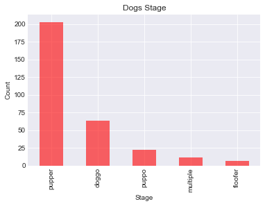

```python
#create bar chart for stage
twitter_archive_master.stage.value_counts().plot(kind = 'bar',
                                                 title = 'Dogs Stage',
                                                 color = 'red',
                                                 alpha = 0.6)
plt.xlabel('Stage')
plt.ylabel('Count')
```

从上图中可以看出狗狗的地位中，pupper 的占比最大，floofer 的占比最小

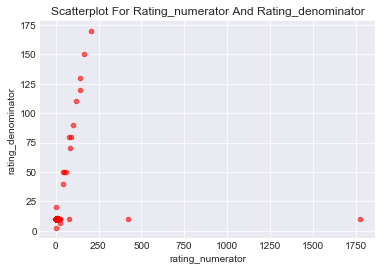

```python
#create scatterplot for rating_numerator and rating_denominator
twitter_archive_master.plot(x = "rating_numerator",y = "rating_denominator",
                            kind = "scatter", title = "Scatterplot For Rating_numerator And Rating_denominator",
                            color = 'red', alpha = 0.6);
```

从上图中可以看出，博主给狗狗们的打分，分子经常超过分母，有两个异常值

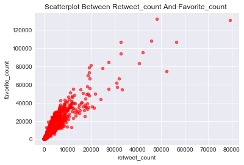

```python
#create scatterplot for retweet_count and favorite_count
twitter_archive_master.plot(x = "retweet_count",y = "favorite_count",
                            kind = "scatter", title = "Scatterplot Between Retweet_count And Favorite_count ",
                            color = "red", alpha = 0.6);
```

retweet_count 转发量与 favorite_count 点赞量成正比关系